# Cell type annotation

Cankun Wang

03/24/2021

# 1 Set working dir

```
## [1] "Current working directory: C:/Users/flyku/Documents/GitHub/NOTCH1-scRNAseq"
```

# 2 Load data

# 3 Identify cell clusters

Shown in the count table and UMAP plot, 16 cell clusters were predicted by Seurat package.

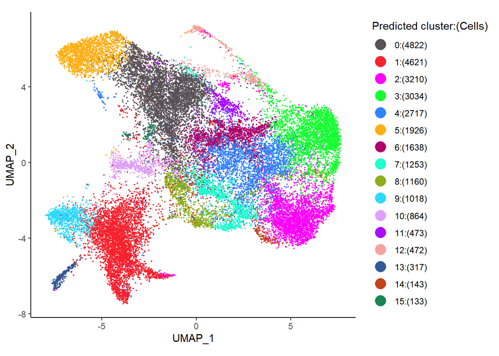

# 4 NOTCH1 expression

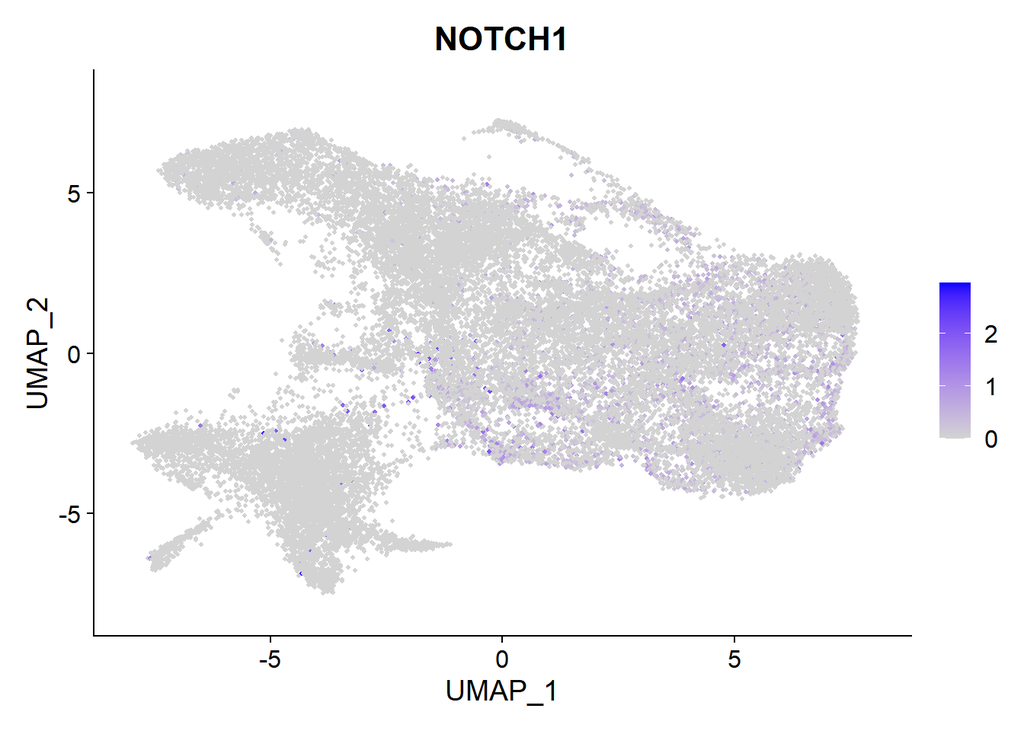

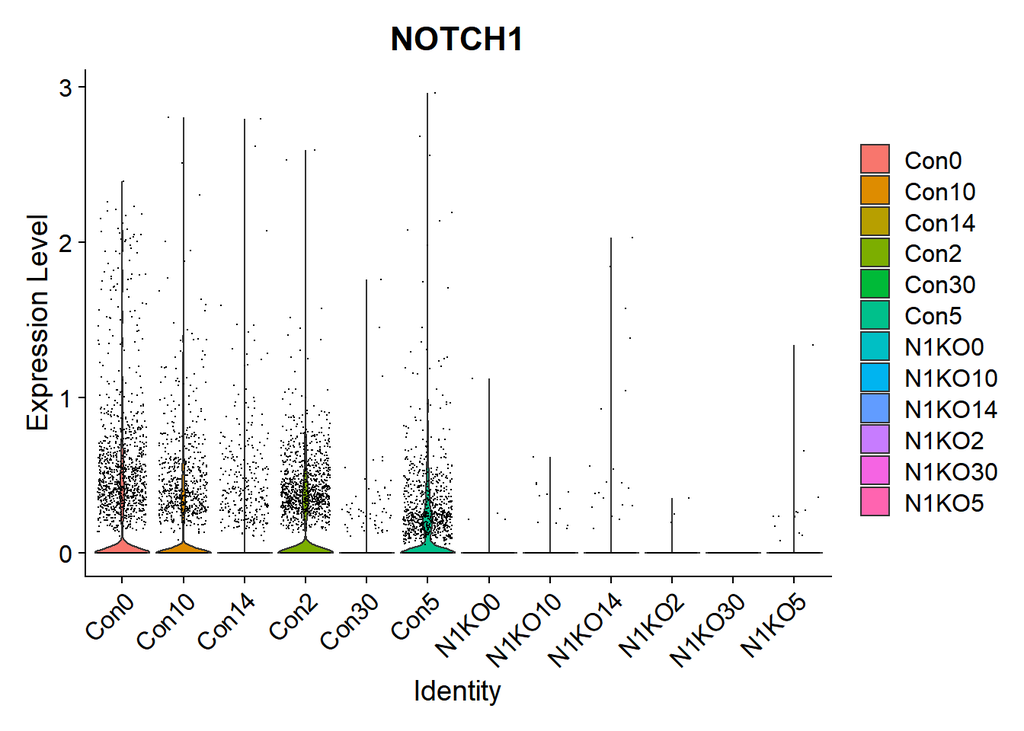

# 5 Cluster-specific genes

The Seurat package FindAllMarkers function was used to identify cluster-specific genes. For example, for cluster 0, the package performs differential testing using cells from cluster 0 vs all other cells. Only genes with log2 fold-change > 0.5 (logfc.threshold=0.5), and genes that are detected in a minimum fraction of 20% (min.pct=0.2) cells in either of the two populations were saved.

Considering too many tables or figures would drastically slow down the rendering of this report. I saved the Cluster-specific genes related results in the ‘cluster_specific_genes’ folder.

# 6 Clusters UMAP plot split by condition

## 6.1 Split by condition

Number of cells for each cluster:

```
##
##           0    1    2    3    4    5    6    7    8    9   10   11   12   13
##   ctrl 1161 2004 1877 1846 1228  834 1134  932 1112  624  493  114  381  122
##   N1KO 3661 2617 1333 1188 1489 1092  504  321   48  394  371  359   91  195
##
##          14   15
##   ctrl  143   11
##   N1KO    0  122
```

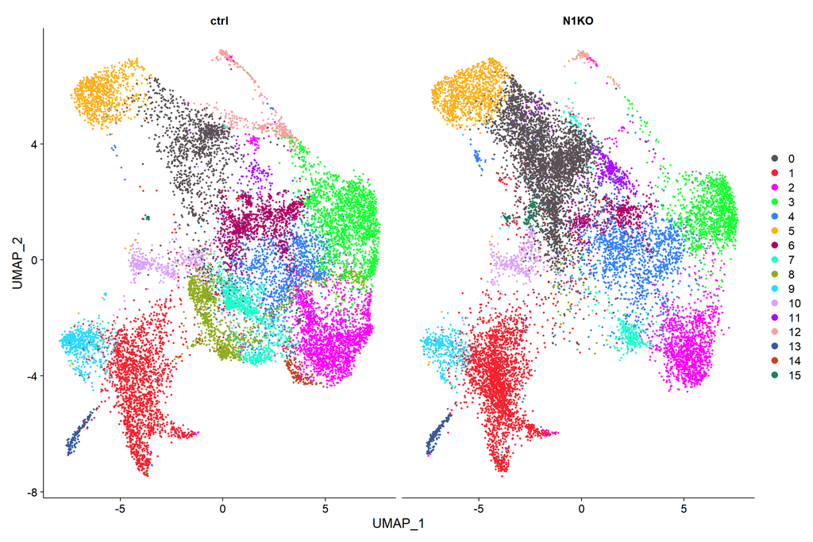

## 6.2 Split by samples

Number of cells for each cluster:

```
##
##             0    1    2    3    4    5    6    7    8    9   10   11   12   13
##   Con0    148  532  801  711  755    1   78   54    7    2  316   19    1    0
##   Con10   476  390  123  152   15  125  113  176  303  111   23   13  225   39
##   Con14   220  363   36   97    4  205   92   53  231  127   12   31  109    4
##   Con2    121  301  661  533  238    0  762  304  223    7    7   14    0    2
##   Con30   175  148   72  100   63  500   28    2    1  365  122   19   46    0
##   Con5     21  270  184  253  153    3   61  343  347   12   13   18    0   77
##   N1KO0    71  879  223  228  247    9   24    7    6   33  169   18    0    0
##   N1KO10  971  568  147  143  114  482   60   60    5  122   45   38   48   68
##   N1KO14 1089  571  107  120  284  166   75   53    4   61   15   66    7   55
##   N1KO2   495  191  707  539  621   13  230  111    4    9   90   44    1    2
##   N1KO30  391  332   12   21  178  224   42    0    0  162   27  184   18    6
##   N1KO5   644   76  137  137   45  198   73   90   29    7   25    9   17   64
##
##            14   15
##   Con0      5    0
##   Con10    10    6
##   Con14     6    3
##   Con2     21    0
##   Con30     0    2
##   Con5    101    0
##   N1KO0     0    0
##   N1KO10    0    8
##   N1KO14    0   13
##   N1KO2     0    0
##   N1KO30    0    8
##   N1KO5     0   93
```

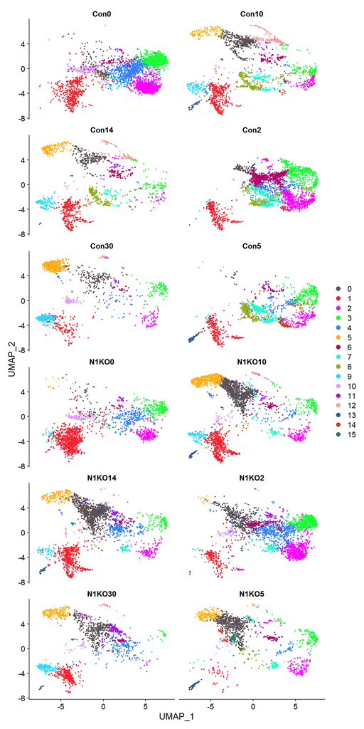

# 7 Predict cell type using SCINA

SCINA and public marker gene database were used to annotate cell type automatically.

This tool is a semi-automatic cell type annotation tool. It uses a marker gene list and gene expression values as input. It achieves good performance from this paper: A comparison of automatic cell identification methods for single-cell RNA sequencing data.

- The input marker gene list is stored at ‘provided_marker.csv’
- The gene expression plots of the cell types are stored in ‘marker_plots’ folder.

Some of genes are not presented in the data, I have renamed some of these genes:

- T -> ?
- FLK1 -> KDR
- CD31 (PECAM-1) -> PECAM1
- SMA -> ?
- TE-7 -> ?

In summary, the tools cannot accurately identify cell types. We might need annoate cell clusters manually.

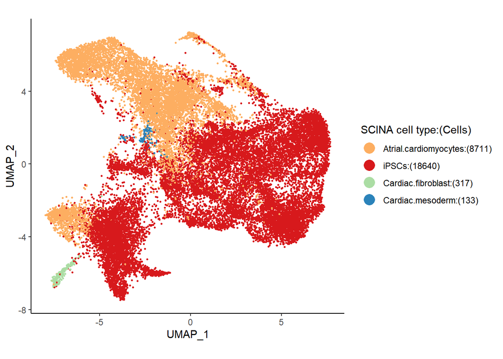

# 8 Transfer cell types from Human Heart Atlas

- Here, we use the Human heart atlas as a reference dataset (486,134 cells, 11 major cardiac cell types, and 62 different cell states). The reference can be used to annotate cell types
- https://www.heartcellatlas.org/#DataSources

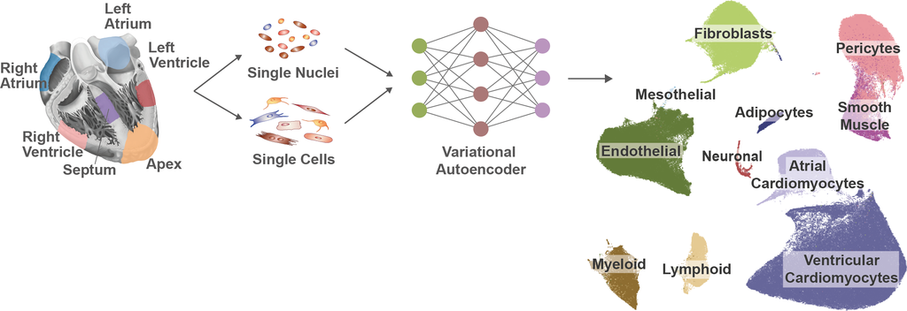

In summary, the transfered cell types are not separated well. We may need to adjust QC parameters and call cell lineage clones first.

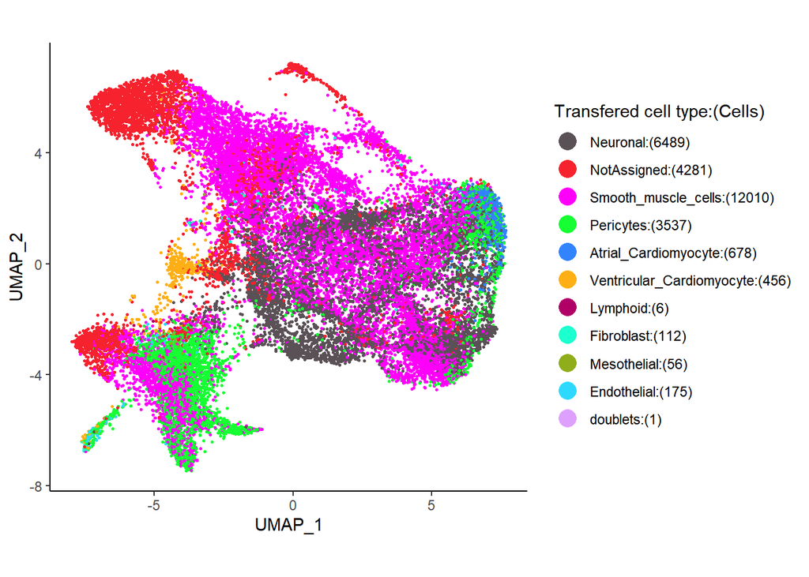